# Homework 2

Jacob Rozran

1/31/2017

## PROBLEM 0

Did you code work? Yes

## PROBLEM 1

```r
SATdat <- read.table("SAT Salary.txt")

names(SATdat) <- c("state","expend","ratio","salary","frac","verbal","math",
                   "total")
```

## PROBLEM 2

I would expect that as teachers make more, the SAT scores get higher. I would expect a positive correlation between SAT score and teacher salary.

## PROBLEM 3

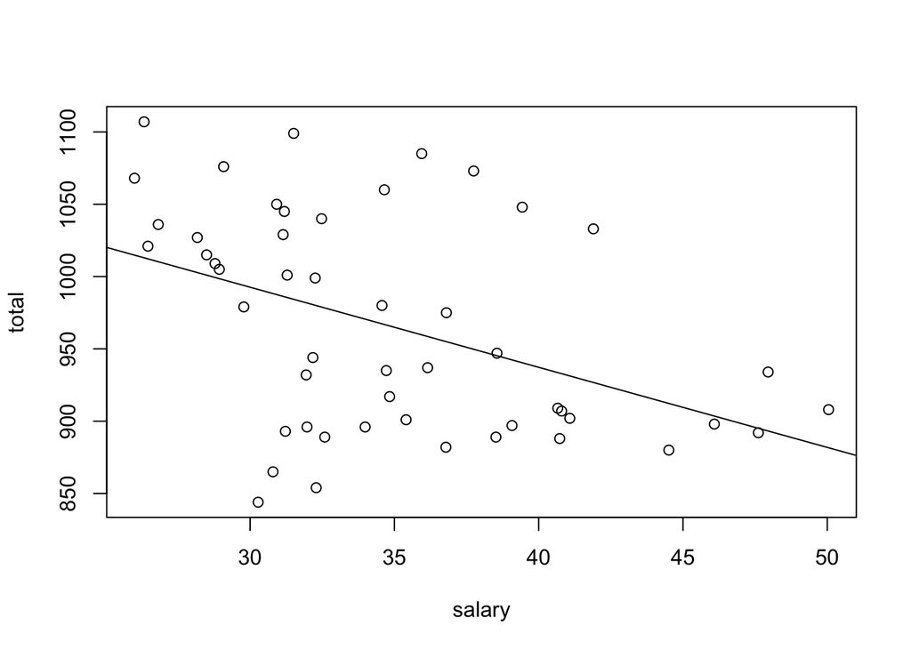

```r
reg_line <- lm(total ~ salary, data = SATdat)

with(SATdat, plot(salary, total))
abline(reg_line)
```

Exactly opposite of what I expected, the correlation between teacher salary and SAT score is negative. Thinking more about it - teachers with the higher scores may be effectively paid more (I haven’t dug into the data); perhaps they live in lower cost-of-living areas and have more support to spend in the classroom.

## PROBLEM 4

The model that is created is:

Y<sub>i</sub> = 1158.8587969 - 5.5396147x<sub>i</sub>, i = 1, 2,…, 50

Where:

- Y<sub>i</sub> = Average SAT Score for the i<sup>th</sup> state
- x<sub>i</sub> = Average teacher salary for the i<sup>th</sup> state

```r
summary(reg_line)
```

```
##
## Call:
## lm(formula = total ~ salary, data = SATdat)
##
## Residuals:
##      Min       1Q   Median       3Q      Max
## -147.125  -45.354    4.073   42.193  125.279
##
## Coefficients:
##             Estimate Std. Error t value Pr(>|t|)
## (Intercept) 1158.859     57.659  20.098  < 2e-16 ***
## salary        -5.540      1.632  -3.394  0.00139 **
## ---
## Signif. codes:  0 '***' 0.001 '**' 0.01 '*' 0.05 '.' 0.1 ' ' 1
##
## Residual standard error: 67.89 on 48 degrees of freedom
## Multiple R-squared:  0.1935, Adjusted R-squared:  0.1767
## F-statistic: 11.52 on 1 and 48 DF,  p-value: 0.001391
```

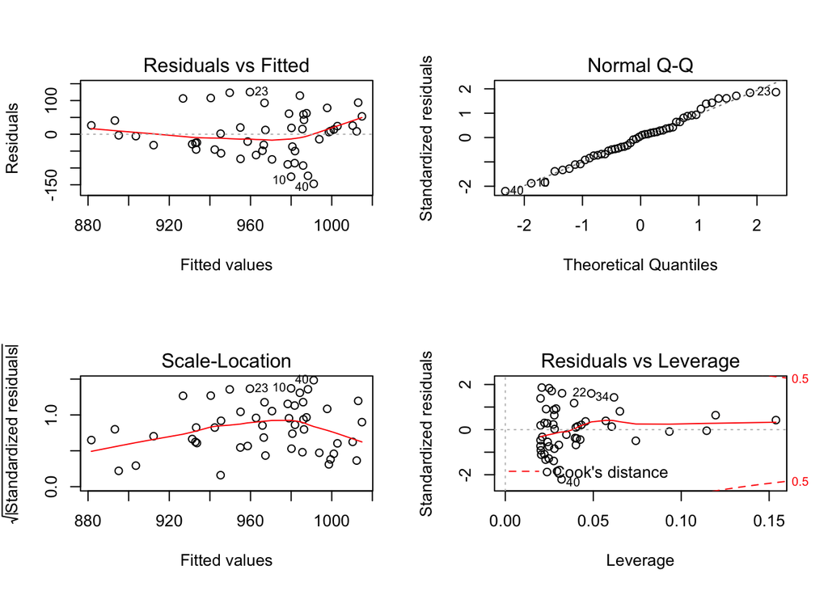

```r
par(mfrow = c(2, 2))
plot(reg_line)
```

To comment on the assumptions:

1. based on the initial scatter plot we created, I would say that there is a linear relationship between average SAT score and average teacher salary.
2. Looking at the normal QQ plot, the data appear to be almost normal. There is some weird trend going on in the upper end that is potentially troublesome.
3. As we are only testing one variable, there is no issues with multi-collinearity in the independent variables.
4. Looking at the residuals vs. fitted plot, I have some concerns about homoscedasticity - I would expect the residuals to be more evenly scattered. This assumption is likely violated, too.

## PROBLEM 5

```r
SATdat$fracgrp <- cut(SATdat$frac,
                      breaks = c(min(SATdat$frac) - 1, 22, 49, max(SATdat$frac)),
                      labels = c("low", "medium", "high"))
```

## PROBLEM 6

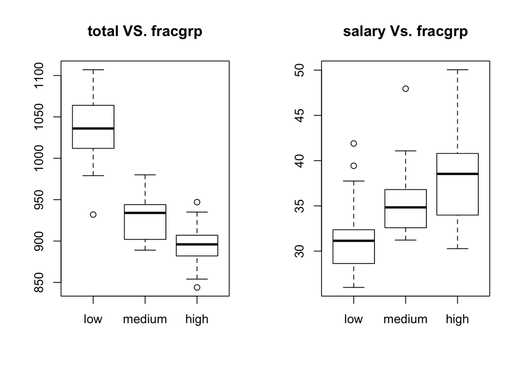

```r
par(mfrow = c(1, 2))

with(SATdat, boxplot(total ~ fracgrp, main = "total VS. fracgrp"))
with(SATdat, boxplot(salary ~ fracgrp, main = "salary Vs. fracgrp"))
```

As the fraction of students taking the exam increases, the average score on the SAT decreases. Conversely, as the fraction of students taking the exam increases, the average teacher salary increases.

The model certainly should take the fraction of students into account - it is leading to a misudnerstanding in the data.

## PROBLEM 7

### With R Base Graphics

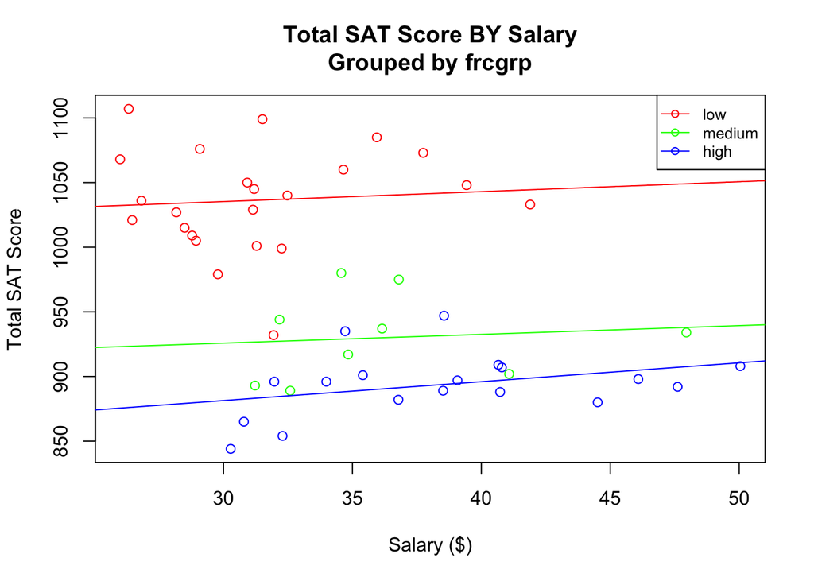

```r
par(mfrow = c(1, 1))

plot(SATdat$total ~ SATdat$salary, type = "n",
     main = "Total SAT Score BY Salary\nGrouped by frcgrp", xlab = "Salary ($)",
     ylab = "Total SAT Score")
points(SATdat$total[SATdat$fracgrp == "low"] ~ SATdat$salary[SATdat$fracgrp == "low"],
       col = "red")
abline(lm(SATdat$total[SATdat$fracgrp == "low"] ~ SATdat$salary[SATdat$fracgrp == "low"]),
       col = "red")
points(SATdat$total[SATdat$fracgrp == "medium"] ~
               SATdat$salary[SATdat$fracgrp == "medium"],
       col = "green")
abline(lm(SATdat$total[SATdat$fracgrp == "medium"] ~
               SATdat$salary[SATdat$fracgrp == "medium"]),
       col = "green")
points(SATdat$total[SATdat$fracgrp == "high"] ~ SATdat$salary[SATdat$fracgrp == "high"],
       col = "blue")
abline(lm(SATdat$total[SATdat$fracgrp == "high"] ~
                  SATdat$salary[SATdat$fracgrp == "high"]),
       col = "blue")
legend("topright", pch = c(1, 1, 1), col = c("red", "green", "blue"), legend = c("low", "medium", "high"), lty = c(1, 1, 1), cex = 0.8)
```

### With GGPLOT

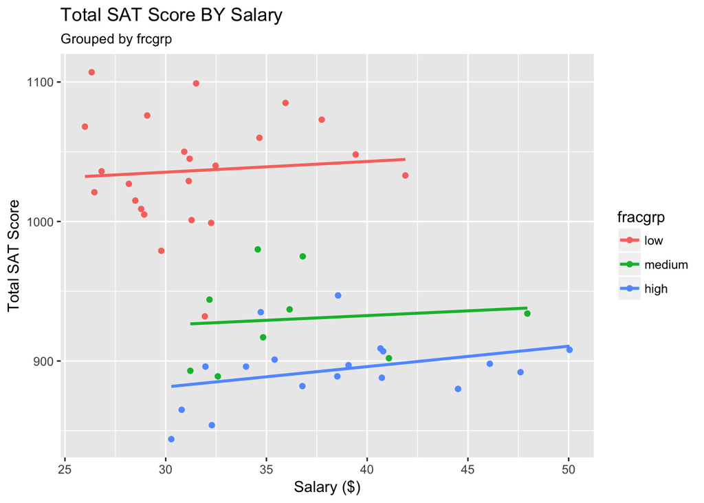

```r
library(ggplot2)

par(mfrow = c(1, 1))

ggplot(SATdat, aes(x = salary, y = total, color = fracgrp)) +
        geom_point() + geom_smooth(method = lm, se = FALSE) +
        ggtitle("Total SAT Score BY Salary",
                subtitle = "Grouped by frcgrp") +
        labs(x = "Salary ($)", y = "Total SAT Score")
```

As salary increases in each group, the scores do go up. This is more true for the “high” fracgrp than it is for the “medium” and “low” fracgrps. This is more along the lines of what I would have expected - as mentioned in #2. Classic example of Simpson’s Paradox.

## PROBLEM 8

H<sub>o</sub>: αβ<sub>ij</sub> are equal for each i, j pair (there is not a significant interaction)  
H<sub>a</sub>: At least one αβ<sub>ij</sub> differs (there is a significant interaction)

```r
mult_mod <- aov(total ~ salary + fracgrp + salary*fracgrp, data = SATdat)

summary(mult_mod)
```

```
##                Df Sum Sq Mean Sq F value   Pr(>F)
## salary          1  53078   53078  43.821 4.14e-08 ***
## fracgrp         2 167777   83889  69.258 2.55e-14 ***
## salary:fracgrp  2    158      79   0.065    0.937
## Residuals      44  53295    1211
## ---
## Signif. codes:  0 '***' 0.001 '**' 0.01 '*' 0.05 '.' 0.1 ' ' 1
```

As 0.937 is not less than 0.05, we do not reject the null hypothesis.

We have overwhelming evidence at the 0.05-level that there is not a significant interaction between fracgrp and salary. I will remove it from the model and rerun the analysis.

H<sub>o</sub>: β<sub>1</sub> = β<sub>2</sub> = β<sub>3</sub>  
H<sub>a</sub>: At least one β<sub>j</sub> differs

```r
mult_mod <- aov(total ~ salary + fracgrp, data = SATdat)

summary(mult_mod)
```

```
##             Df Sum Sq Mean Sq F value   Pr(>F)
## salary       1  53078   53078   45.68 2.10e-08 ***
## fracgrp      2 167777   83889   72.19 6.48e-15 ***
## Residuals   46  53453    1162
## ---
## Signif. codes:  0 '***' 0.001 '**' 0.01 '*' 0.05 '.' 0.1 ' ' 1
```

```r
TukeyHSD(mult_mod, "fracgrp", ordered = TRUE)
```

```
##   Tukey multiple comparisons of means
##     95% family-wise confidence level
##     factor levels have been ordered
##
## Fit: aov(formula = total ~ salary + fracgrp, data = SATdat)
##
## $fracgrp
##                  diff       lwr       upr     p adj
## medium-high  24.61674 -9.086639  58.32012 0.1913667
## low-high    103.10854 77.128440 129.08864 0.0000000
## low-medium   78.49180 46.032519 110.95108 0.0000014
```

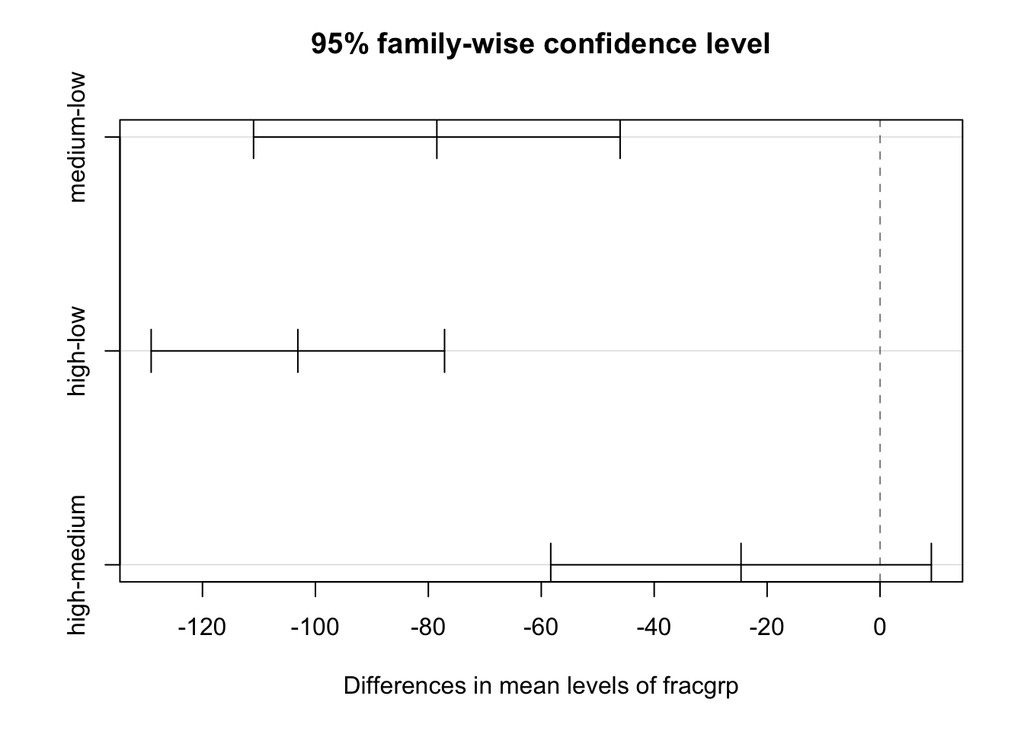

```r
plot(TukeyHSD(mult_mod, "fracgrp"))
```